# A Visualization for Ford GoBike

```python
#View the first 5 of the dataframe
df4.head()
```

|  | duration_sec | start_time | end_time | start_station_id | start_station_name | start_station_latitude | start_station_longitude | end_station_id | end_station_name | end_station_latitude | end_station_longitude | bike_id | user_type | member_birth_year | member_gender | bike_share_for_all_trip |
| --- | --- | --- | --- | --- | --- | --- | --- | --- | --- | --- | --- | --- | --- | --- | --- | --- |
| 0 | 72393 | 2018-04-30 22:49:32.6180 | 2018-05-01 18:56:06.3010 | 4 | Cyril Magnin St at Ellis St | 37.785881 | -122.408915 | 4 | Cyril Magnin St at Ellis St | 37.785881 | -122.408915 | 3940 | Customer | NaN | NaN | No |
| 1 | 81034 | 2018-04-30 17:46:04.9970 | 2018-05-01 16:16:39.2470 | 122 | 19th St at Mission St | 37.760299 | -122.418892 | 42 | San Francisco City Hall (Polk St at Grove St) | 37.778650 | -122.418230 | 3374 | Customer | NaN | NaN | No |
| 2 | 86142 | 2018-04-30 16:07:13.9190 | 2018-05-01 16:02:56.7170 | 41 | Golden Gate Ave at Polk St | 37.781270 | -122.418740 | 67 | San Francisco Caltrain Station 2 (Townsend St... | 37.776639 | -122.395526 | 3191 | Subscriber | 1974.0 | Male | Yes |
| 3 | 68839 | 2018-04-30 17:11:57.4640 | 2018-05-01 12:19:16.7870 | 284 | Yerba Buena Center for the Arts (Howard St at ... | 37.784872 | -122.400876 | 115 | Jackson Playground | 37.765026 | -122.398773 | 2970 | Customer | 1974.0 | Female | No |
| 4 | 59091 | 2018-04-30 18:45:21.5560 | 2018-05-01 11:10:13.5410 | 196 | Grand Ave at Perkins St | 37.808894 | -122.256460 | 233 | 12th St at 4th Ave | 37.795812 | -122.255555 | 522 | Customer | 1965.0 | Male | No |

```python
#View the first 5 of the dataframe
df5.head()
```

|  | duration_sec | start_time | end_time | start_station_id | start_station_name | start_station_latitude | start_station_longitude | end_station_id | end_station_name | end_station_latitude | end_station_longitude | bike_id | user_type | member_birth_year | member_gender | bike_share_for_all_trip |
| --- | --- | --- | --- | --- | --- | --- | --- | --- | --- | --- | --- | --- | --- | --- | --- | --- |
| 0 | 56791 | 2018-05-31 21:41:51.4750 | 2018-06-01 13:28:22.7220 | 44 | Civic Center/UN Plaza BART Station (Market St ... | 37.781074 | -122.411738 | 78 | Folsom St at 9th St | 37.773717 | -122.411647 | 1230 | Customer | NaN | NaN | No |
| 1 | 52797 | 2018-05-31 18:39:53.7690 | 2018-06-01 09:19:51.5410 | 186 | Lakeside Dr at 14th St | 37.801319 | -122.262642 | 338 | 13th St at Franklin St | 37.803189 | -122.270579 | 3414 | Subscriber | 1983.0 | Male | No |
| 2 | 43204 | 2018-05-31 21:09:48.0150 | 2018-06-01 09:09:52.4850 | 17 | Embarcadero BART Station (Beale St at Market St) | 37.792251 | -122.397086 | 93 | 4th St at Mission Bay Blvd S | 37.770407 | -122.391198 | 2677 | Customer | NaN | NaN | No |
| 3 | 67102 | 2018-05-31 14:09:54.9720 | 2018-06-01 08:48:17.8150 | 106 | Sanchez St at 17th St | 37.763242 | -122.430675 | 47 | 4th St at Harrison St | 37.780955 | -122.399749 | 4224 | Subscriber | 1979.0 | Male | No |
| 4 | 58883 | 2018-05-31 16:07:23.8570 | 2018-06-01 08:28:47.2020 | 16 | Steuart St at Market St | 37.794130 | -122.394430 | 30 | San Francisco Caltrain (Townsend St at 4th St) | 37.776598 | -122.395282 | 3392 | Subscriber | 1986.0 | Male | No |

```python
#View the first 5 of the dataframe
df6.head()
```

|  | duration_sec | start_time | end_time | start_station_id | start_station_name | start_station_latitude | start_station_longitude | end_station_id | end_station_name | end_station_latitude | end_station_longitude | bike_id | user_type | member_birth_year | member_gender | bike_share_for_all_trip |
| --- | --- | --- | --- | --- | --- | --- | --- | --- | --- | --- | --- | --- | --- | --- | --- | --- |
| 0 | 59088 | 2018-06-30 23:32:44.6590 | 2018-07-01 15:57:33.3160 | 76.0 | McCoppin St at Valencia St | 37.771662 | -122.422423 | 95.0 | Sanchez St at 15th St | 37.766219 | -122.431060 | 2100 | Subscriber | 1975.0 | Male | Yes |
| 1 | 60358 | 2018-06-30 21:48:19.5570 | 2018-07-01 14:34:18.1000 | 248.0 | Telegraph Ave at Ashby Ave | 37.855956 | -122.259795 | 239.0 | Bancroft Way at Telegraph Ave | 37.868813 | -122.258764 | 653 | Customer | NaN | NaN | No |
| 2 | 63654 | 2018-06-30 20:26:53.0310 | 2018-07-01 14:07:47.2320 | 23.0 | The Embarcadero at Steuart St | 37.791464 | -122.391034 | 50.0 | 2nd St at Townsend St | 37.780526 | -122.390288 | 3235 | Subscriber | 1962.0 | Female | No |
| 3 | 50508 | 2018-06-30 20:29:59.8130 | 2018-07-01 10:31:48.2500 | 58.0 | Market St at 10th St | 37.776619 | -122.417385 | 88.0 | 11th St at Bryant St | 37.770030 | -122.411726 | 3675 | Subscriber | 1992.0 | Male | No |
| 4 | 51697 | 2018-06-30 18:24:56.6960 | 2018-07-01 08:46:33.7390 | 196.0 | Grand Ave at Perkins St | 37.808894 | -122.256460 | 272.0 | Woolsey St at Sacramento St | 37.850578 | -122.278175 | 3232 | Customer | 1989.0 | Female | No |

```python
#View the first 5 of the dataframe
df7.head()
```

|  | duration_sec | start_time | end_time | start_station_id | start_station_name | start_station_latitude | start_station_longitude | end_station_id | end_station_name | end_station_latitude | end_station_longitude | bike_id | user_type | member_birth_year | member_gender | bike_share_for_all_trip |
| --- | --- | --- | --- | --- | --- | --- | --- | --- | --- | --- | --- | --- | --- | --- | --- | --- |
| 0 | 59989 | 2018-07-31 18:20:32.7230 | 2018-08-01 11:00:22.1890 | 197.0 | El Embarcadero at Grand Ave | 37.808848 | -122.249680 | 181.0 | Grand Ave at Webster St | 37.811377 | -122.265192 | 1953 | Customer | 1995.0 | Male | No |
| 1 | 60232 | 2018-07-31 17:24:26.2350 | 2018-08-01 10:08:18.7520 | 77.0 | 11th St at Natoma St | 37.773507 | -122.416040 | 356.0 | Valencia St at Clinton Park | 37.769188 | -122.422285 | 3010 | Subscriber | 1994.0 | Female | No |
| 2 | 43864 | 2018-07-31 21:03:26.7030 | 2018-08-01 09:14:30.8340 | NaN | NaN | 37.410000 | -121.940000 | NaN | NaN | 37.410000 | -121.940000 | 4273 | Subscriber | 1998.0 | Male | No |
| 3 | 51522 | 2018-07-31 18:54:23.7210 | 2018-08-01 09:13:06.6610 | 114.0 | Rhode Island St at 17th St | 37.764478 | -122.402570 | 345.0 | Hubbell St at 16th St | 37.766474 | -122.398295 | 1043 | Subscriber | 1990.0 | Female | No |
| 4 | 83380 | 2018-07-31 09:22:29.1000 | 2018-08-01 08:32:09.2700 | 213.0 | 32nd St at Adeline St | 37.823847 | -122.281193 | 198.0 | Snow Park | 37.807813 | -122.264496 | 1336 | Subscriber | 1982.0 | Male | No |

```python
#View the first 5 of the dataframe
df8.head()
```

|  | duration_sec | start_time | end_time | start_station_id | start_station_name | start_station_latitude | start_station_longitude | end_station_id | end_station_name | end_station_latitude | end_station_longitude | bike_id | user_type | member_birth_year | member_gender | bike_share_for_all_trip |
| --- | --- | --- | --- | --- | --- | --- | --- | --- | --- | --- | --- | --- | --- | --- | --- | --- |
| 0 | 69465 | 2018-08-31 19:18:08.6130 | 2018-09-01 14:35:54.0640 | 3.0 | Powell St BART Station (Market St at 4th St) | 37.786375 | -122.404904 | 3.0 | Powell St BART Station (Market St at 4th St) | 37.786375 | -122.404904 | 813 | Customer | NaN | NaN | No |
| 1 | 60644 | 2018-08-31 21:40:01.7490 | 2018-09-01 14:30:46.4470 | 50.0 | 2nd St at Townsend St | 37.780526 | -122.390288 | 50.0 | 2nd St at Townsend St | 37.780526 | -122.390288 | 1964 | Subscriber | 1990.0 | Male | No |
| 2 | 57922 | 2018-08-31 20:04:28.1630 | 2018-09-01 12:09:50.8240 | 17.0 | Embarcadero BART Station (Beale St at Market St) | 37.792251 | -122.397086 | 30.0 | San Francisco Caltrain (Townsend St at 4th St) | 37.776598 | -122.395282 | 535 | Customer | 1997.0 | Male | No |
| 3 | 82573 | 2018-08-31 13:07:14.9020 | 2018-09-01 12:03:28.2600 | 19.0 | Post St at Kearny St | 37.788975 | -122.403452 | 34.0 | Father Alfred E Boeddeker Park | 37.783988 | -122.412408 | 3080 | Customer | 2000.0 | Female | No |
| 4 | 57677 | 2018-08-31 19:48:45.1980 | 2018-09-01 11:50:03.1560 | 3.0 | Powell St BART Station (Market St at 4th St) | 37.786375 | -122.404904 | 3.0 | Powell St BART Station (Market St at 4th St) | 37.786375 | -122.404904 | 132 | Customer | NaN | NaN | No |

```python
#View the first 5 of the dataframe
df9.head()
```

|  | duration_sec | start_time | end_time | start_station_id | start_station_name | start_station_latitude | start_station_longitude | end_station_id | end_station_name | end_station_latitude | end_station_longitude | bike_id | user_type | member_birth_year | member_gender | bike_share_for_all_trip |
| --- | --- | --- | --- | --- | --- | --- | --- | --- | --- | --- | --- | --- | --- | --- | --- | --- |
| 0 | 76491 | 2018-09-30 18:37:01.7710 | 2018-10-01 15:51:53.5530 | 120.0 | Mission Dolores Park | 37.761420 | -122.426435 | 26.0 | 1st St at Folsom St | 37.787290 | -122.394380 | 903 | Customer | 1998.0 | Female | No |
| 1 | 50832 | 2018-09-30 19:49:31.9530 | 2018-10-01 09:56:44.7320 | NaN | NaN | 37.410000 | -121.940000 | NaN | NaN | 37.410000 | -121.940000 | 4154 | Customer | 1992.0 | Male | No |
| 2 | 74498 | 2018-09-30 11:34:44.7970 | 2018-10-01 08:16:23.3570 | 55.0 | Webster St at Grove St | 37.777053 | -122.429558 | 55.0 | Webster St at Grove St | 37.777053 | -122.429558 | 2696 | Customer | NaN | NaN | No |
| 3 | 79396 | 2018-09-30 10:12:49.9400 | 2018-10-01 08:16:06.0440 | 11.0 | Davis St at Jackson St | 37.797280 | -122.398436 | 55.0 | Webster St at Grove St | 37.777053 | -122.429558 | 2458 | Customer | 1990.0 | Male | No |
| 4 | 60287 | 2018-09-30 15:28:03.5560 | 2018-10-01 08:12:50.7870 | 15.0 | San Francisco Ferry Building (Harry Bridges Pl... | 37.795392 | -122.394203 | 15.0 | San Francisco Ferry Building (Harry Bridges Pl... | 37.795392 | -122.394203 | 2497 | Customer | NaN | NaN | No |

```python
#View the first 5 of the dataframe
df10.head()
```

|  | duration_sec | start_time | end_time | start_station_id | start_station_name | start_station_latitude | start_station_longitude | end_station_id | end_station_name | end_station_latitude | end_station_longitude | bike_id | user_type | member_birth_year | member_gender | bike_share_for_all_trip |
| --- | --- | --- | --- | --- | --- | --- | --- | --- | --- | --- | --- | --- | --- | --- | --- | --- |
| 0 | 80066 | 2018-10-31 20:49:03.1400 | 2018-11-01 19:03:30.0550 | 138.0 | Jersey St at Church St | 37.750900 | -122.427411 | 147.0 | 29th St at Tiffany Ave | 37.744067 | -122.421472 | 3458 | Customer | 1987.0 | Female | No |
| 1 | 56428 | 2018-10-31 20:18:02.8810 | 2018-11-01 11:58:31.1460 | 75.0 | Market St at Franklin St | 37.773793 | -122.421239 | 86.0 | Market St at Dolores St | 37.769305 | -122.426826 | 1798 | Customer | NaN | NaN | No |
| 2 | 44825 | 2018-10-31 20:07:13.3780 | 2018-11-01 08:34:19.3670 | 139.0 | Garfield Square (25th St at Harrison St) | 37.751017 | -122.411901 | 122.0 | 19th St at Mission St | 37.760299 | -122.418892 | 1575 | Customer | 1983.0 | Female | No |
| 3 | 55461 | 2018-10-31 17:06:37.6830 | 2018-11-01 08:30:59.2200 | 67.0 | San Francisco Caltrain Station 2 (Townsend St... | 37.776639 | -122.395526 | 16.0 | Steuart St at Market St | 37.794130 | -122.394430 | 2978 | Subscriber | 1992.0 | Female | No |
| 4 | 47724 | 2018-10-31 18:27:36.8230 | 2018-11-01 07:43:01.5610 | 259.0 | Addison St at Fourth St | 37.866249 | -122.299371 | 259.0 | Addison St at Fourth St | 37.866249 | -122.299371 | 2392 | Customer | NaN | NaN | No |

```python
#View the first 5 of the dataframe
df11.head()
```

|  | duration_sec | start_time | end_time | start_station_id | start_station_name | start_station_latitude | start_station_longitude | end_station_id | end_station_name | end_station_latitude | end_station_longitude | bike_id | user_type | member_birth_year | member_gender | bike_share_for_all_trip |
| --- | --- | --- | --- | --- | --- | --- | --- | --- | --- | --- | --- | --- | --- | --- | --- | --- |
| 0 | 79489 | 2018-11-30 13:40:32.7690 | 2018-12-01 11:45:21.9720 | NaN | NaN | 37.420000 | -121.940000 | NaN | NaN | 37.410000 | -121.940000 | 4105 | Customer | 1982.0 | Female | No |
| 1 | 42847 | 2018-11-30 20:13:45.5090 | 2018-12-01 08:07:53.1330 | 37.0 | 2nd St at Folsom St | 37.785000 | -122.395936 | 30.0 | San Francisco Caltrain (Townsend St at 4th St) | 37.776598 | -122.395282 | 2614 | Customer | 1992.0 | Male | No |
| 2 | 1128 | 2018-11-30 23:58:26.4310 | 2018-12-01 00:17:14.4880 | 249.0 | Russell St at College Ave | 37.858473 | -122.253253 | 249.0 | Russell St at College Ave | 37.858473 | -122.253253 | 1496 | Subscriber | 1998.0 | Male | Yes |
| 3 | 2476 | 2018-11-30 23:35:06.7230 | 2018-12-01 00:16:23.4740 | 104.0 | 4th St at 16th St | 37.767045 | -122.390833 | 15.0 | San Francisco Ferry Building (Harry Bridges Pl... | 37.795392 | -122.394203 | 1334 | Subscriber | 1959.0 | Male | No |
| 4 | 1273 | 2018-11-30 23:54:12.3890 | 2018-12-01 00:15:26.3680 | 44.0 | Civic Center/UN Plaza BART Station (Market St ... | 37.781074 | -122.411738 | 60.0 | 8th St at Ringold St | 37.774520 | -122.409449 | 393 | Subscriber | 1993.0 | Female | Yes |

```python
#View the first 5 of the dataframe
df12.head()
```

|  | duration_sec | start_time | end_time | start_station_id | start_station_name | start_station_latitude | start_station_longitude | end_station_id | end_station_name | end_station_latitude | end_station_longitude | bike_id | user_type | member_birth_year | member_gender | bike_share_for_all_trip |
| --- | --- | --- | --- | --- | --- | --- | --- | --- | --- | --- | --- | --- | --- | --- | --- | --- |
| 0 | 68529 | 2018-12-31 20:03:11.7350 | 2019-01-01 15:05:21.5580 | 217.0 | 27th St at MLK Jr Way | 37.817015 | -122.271761 | 217.0 | 27th St at MLK Jr Way | 37.817015 | -122.271761 | 3305 | Customer | NaN | NaN | No |
| 1 | 63587 | 2018-12-31 19:00:32.1210 | 2019-01-01 12:40:19.3660 | NaN | NaN | 37.400000 | -121.940000 | NaN | NaN | 37.400000 | -121.940000 | 4281 | Customer | 1995.0 | Male | No |
| 2 | 64169 | 2018-12-31 15:09:01.0820 | 2019-01-01 08:58:30.0910 | NaN | NaN | 37.400000 | -121.940000 | NaN | NaN | 37.400000 | -121.940000 | 4267 | Customer | 1988.0 | Male | No |
| 3 | 30550 | 2018-12-31 19:26:20.7750 | 2019-01-01 03:55:30.7930 | 13.0 | Commercial St at Montgomery St | 37.794231 | -122.402923 | 19.0 | Post St at Kearny St | 37.788975 | -122.403452 | 5422 | Subscriber | 1986.0 | Male | Yes |
| 4 | 2150 | 2018-12-31 23:59:12.0970 | 2019-01-01 00:35:02.1530 | 3.0 | Powell St BART Station (Market St at 4th St) | 37.786375 | -122.404904 | 368.0 | Myrtle St at Polk St | 37.785434 | -122.419622 | 4820 | Customer | NaN | NaN | No |

```python
# After verifying the data is the same, I will now merge the dataframes
path = r'C:\Users\JrGMachine\iCloudDrive\Data AnalystUdacity\CommunicateDataFindings'
files = glob.glob(os.path.join(path, "*.csv"))
df = pd.concat((pd.read_csv(f) for f in files), ignore_index = True, sort = False)
df.to_csv('df_master.csv')
```

```python
# Load the newly merged dataset to a new dataframe
df = pd.read_csv('df_master.csv', index_col=0)

#View the first 5 of the dataframe
df.head()
```

|  | duration_sec | start_time | end_time | start_station_id | start_station_name | start_station_latitude | start_station_longitude | end_station_id | end_station_name | end_station_latitude | end_station_longitude | bike_id | user_type | member_birth_year | member_gender | bike_share_for_all_trip | Unnamed: 0.1 | Unnamed: 0.1.1 | Unnamed: 0.1.1.1 |
| --- | --- | --- | --- | --- | --- | --- | --- | --- | --- | --- | --- | --- | --- | --- | --- | --- | --- | --- | --- |
| 0 | 75284 | 2018-01-31 22:52:35.2390 | 2018-02-01 19:47:19.8240 | 120.0 | Mission Dolores Park | 37.761420 | -122.426435 | 285.0 | Webster St at O'Farrell St | 37.783521 | -122.431158 | 2765 | Subscriber | 1986.0 | Male | No | NaN | NaN | NaN |
| 1 | 85422 | 2018-01-31 16:13:34.3510 | 2018-02-01 15:57:17.3100 | 15.0 | San Francisco Ferry Building (Harry Bridges Pl... | 37.795392 | -122.394203 | 15.0 | San Francisco Ferry Building (Harry Bridges Pl... | 37.795392 | -122.394203 | 2815 | Customer | NaN | NaN | No | NaN | NaN | NaN |
| 2 | 71576 | 2018-01-31 14:23:55.8890 | 2018-02-01 10:16:52.1160 | 304.0 | Jackson St at 5th St | 37.348759 | -121.894798 | 296.0 | 5th St at Virginia St | 37.325998 | -121.877120 | 3039 | Customer | 1996.0 | Male | No | NaN | NaN | NaN |
| 3 | 61076 | 2018-01-31 14:53:23.5620 | 2018-02-01 07:51:20.5000 | 75.0 | Market St at Franklin St | 37.773793 | -122.421239 | 47.0 | 4th St at Harrison St | 37.780955 | -122.399749 | 321 | Customer | NaN | NaN | No | NaN | NaN | NaN |
| 4 | 39966 | 2018-01-31 19:52:24.6670 | 2018-02-01 06:58:31.0530 | 74.0 | Laguna St at Hayes St | 37.776435 | -122.426244 | 19.0 | Post St at Kearny St | 37.788975 | -122.403452 | 617 | Subscriber | 1991.0 | Male | No | NaN | NaN | NaN |

```python
#Verify the information
df.info()
```

```
<class 'pandas.core.frame.DataFrame'>
Int64Index: 7454884 entries, 0 to 7454883
Data columns (total 19 columns):
duration_sec               int64
start_time                 object
end_time                   object
start_station_id           float64
start_station_name         object
start_station_latitude     float64
start_station_longitude    float64
end_station_id             float64
end_station_name           object
end_station_latitude       float64
end_station_longitude      float64
bike_id                    int64
user_type                  object
member_birth_year          float64
member_gender              object
bike_share_for_all_trip    object
Unnamed: 0.1               float64
Unnamed: 0.1.1             float64
Unnamed: 0.1.1.1           float64
dtypes: float64(10), int64(2), object(7)
memory usage: 1.1+ GB
```

```python
#Checking for duplicated values
df.duplicated().unique()
```

```
array([False])
```

```python
#Check the stats for the dataframe
df.describe()
```

|  | duration_sec | start_station_id | start_station_latitude | start_station_longitude | end_station_id | end_station_latitude | end_station_longitude | bike_id | member_birth_year | Unnamed: 0.1 | Unnamed: 0.1.1 | Unnamed: 0.1.1.1 |
| --- | --- | --- | --- | --- | --- | --- | --- | --- | --- | --- | --- | --- |
| count | 7.454884e+06 | 7.407800e+06 | 7.454884e+06 | 7.454884e+06 | 7.407800e+06 | 7.454884e+06 | 7.454884e+06 | 7.454884e+06 | 7.012012e+06 | 5.591163e+06 | 3.727442e+06 | 1.863721e+06 |
| mean | 8.573026e+02 | 1.196744e+02 | 3.776678e+01 | -1.223492e+02 | 1.181730e+02 | 3.776690e+01 | -1.223487e+02 | 2.296851e+03 | 1.983088e+03 | 2.795581e+06 | 1.863720e+06 | 9.318600e+05 |
| std | 2.370378e+03 | 1.003975e+02 | 1.057689e-01 | 1.654634e-01 | 1.004402e+02 | 1.056483e-01 | 1.650596e-01 | 1.287732e+03 | 1.044288e+01 | 1.614030e+06 | 1.076020e+06 | 5.380101e+05 |
| min | 6.100000e+01 | 3.000000e+00 | 3.726331e+01 | -1.224737e+02 | 3.000000e+00 | 3.726331e+01 | -1.224737e+02 | 1.100000e+01 | 1.881000e+03 | 0.000000e+00 | 0.000000e+00 | 0.000000e+00 |
| 25% | 3.500000e+02 | 3.300000e+01 | 3.777106e+01 | -1.224114e+02 | 3.000000e+01 | 3.777106e+01 | -1.224094e+02 | 1.225000e+03 | 1.978000e+03 | 1.397790e+06 | 9.318602e+05 | 4.659300e+05 |
| 50% | 5.560000e+02 | 8.900000e+01 | 3.778107e+01 | -1.223974e+02 | 8.800000e+01 | 3.778127e+01 | -1.223971e+02 | 2.338000e+03 | 1.985000e+03 | 2.795581e+06 | 1.863720e+06 | 9.318600e+05 |
| 75% | 8.720000e+02 | 1.860000e+02 | 3.779625e+01 | -1.222865e+02 | 1.830000e+02 | 3.779728e+01 | -1.222894e+02 | 3.333000e+03 | 1.991000e+03 | 4.193372e+06 | 2.795581e+06 | 1.397790e+06 |
| max | 8.636600e+04 | 3.810000e+02 | 4.551000e+01 | -7.357000e+01 | 3.810000e+02 | 4.551000e+01 | -7.357000e+01 | 6.234000e+03 | 2.000000e+03 | 5.591162e+06 | 3.727441e+06 | 1.863720e+06 |

```python
#Check a random sample of 15 rows for data descrepancies
df.sample(15)
```

|  | duration_sec | start_time | end_time | start_station_id | start_station_name | start_station_latitude | start_station_longitude | end_station_id | end_station_name | end_station_latitude | end_station_longitude | bike_id | user_type | member_birth_year | member_gender | bike_share_for_all_trip | Unnamed: 0.1 | Unnamed: 0.1.1 | Unnamed: 0.1.1.1 |
| --- | --- | --- | --- | --- | --- | --- | --- | --- | --- | --- | --- | --- | --- | --- | --- | --- | --- | --- | --- |
| 7317985 | 719 | 2018-11-01 17:51:01.0510 | 2018-11-01 18:03:01.0500 | 364.0 | Mission Rock St at 3rd St | 37.772886 | -122.389940 | 15.0 | San Francisco Ferry Building (Harry Bridges Pl... | 37.795392 | -122.394203 | 1852 | Subscriber | 1972.0 | Male | No | 5454264.0 | 3590543.0 | 1726822.0 |
| 6294195 | 756 | 2018-06-19 11:51:27.5290 | 2018-06-19 12:04:03.7190 | 79.0 | 7th St at Brannan St | 37.773492 | -122.403673 | 129.0 | Harrison St at 20th St | 37.758862 | -122.412544 | 1329 | Subscriber | 1985.0 | Female | No | 4430474.0 | 2566753.0 | 703032.0 |
| 734080 | 1561 | 2018-06-14 08:53:48.3420 | 2018-06-14 09:19:50.3340 | 132.0 | 24th St at Chattanooga St | 37.751819 | -122.426614 | 21.0 | Montgomery St BART Station (Market St at 2nd St) | 37.789625 | -122.400811 | 1656 | Subscriber | 1981.0 | Female | No | NaN | NaN | NaN |
| 7388039 | 302 | 2018-12-14 16:23:58.4370 | 2018-12-14 16:29:00.5550 | 102.0 | Irwin St at 8th St | 37.766883 | -122.399579 | 89.0 | Division St at Potrero Ave | 37.769218 | -122.407646 | 5259 | Subscriber | 1991.0 | Other | No | 5524318.0 | 3660597.0 | 1796876.0 |
| 3286459 | 775 | 2018-10-27 18:32:36.7580 | 2018-10-27 18:45:32.1480 | 250.0 | North Berkeley BART Station | 37.873558 | -122.283093 | 254.0 | Vine St at Shattuck Ave | 37.880222 | -122.269592 | 2214 | Subscriber | 1960.0 | Female | No | 1422738.0 | NaN | NaN |
| 4701290 | 651 | 2018-07-09 09:11:19.6130 | 2018-07-09 09:22:10.9180 | 81.0 | Berry St at 4th St | 37.775880 | -122.393170 | 15.0 | San Francisco Ferry Building (Harry Bridges Pl... | 37.795392 | -122.394203 | 1285 | Subscriber | 1997.0 | Female | No | 2837569.0 | 973848.0 | NaN |
| 2959722 | 854 | 2018-08-19 16:31:13.2130 | 2018-08-19 16:45:27.8880 | 75.0 | Market St at Franklin St | 37.773793 | -122.421239 | 285.0 | Webster St at O'Farrell St | 37.783521 | -122.431158 | 1090 | Subscriber | 1987.0 | Male | No | 1096001.0 | NaN | NaN |
| 3307970 | 434 | 2018-10-24 14:23:39.4910 | 2018-10-24 14:30:54.3290 | 292.0 | Empire St at 1st St | 37.344882 | -121.896966 | 289.0 | 5th St at Taylor St | 37.351017 | -121.895921 | 189 | Subscriber | 1957.0 | Male | Yes | 1444249.0 | NaN | NaN |
| 5253775 | 152 | 2018-10-11 14:48:12.7870 | 2018-10-11 14:50:45.4240 | 341.0 | Fountain Alley at S 2nd St | 37.336188 | -121.889277 | 310.0 | San Fernando St at 4th St | 37.335885 | -121.885660 | 696 | Subscriber | 1995.0 | Male | Yes | 3390054.0 | 1526333.0 | NaN |
| 6149798 | 987 | 2018-05-11 16:19:42.9430 | 2018-05-11 16:36:10.7480 | 99.0 | Folsom St at 15th St | 37.767037 | -122.415443 | 284.0 | Yerba Buena Center for the Arts (Howard St at ... | 37.784872 | -122.400876 | 2826 | Subscriber | 1980.0 | Male | No | 4286077.0 | 2422356.0 | 558635.0 |
| 6346367 | 750 | 2018-06-11 15:18:38.3900 | 2018-06-11 15:31:09.3810 | 86.0 | Market St at Dolores St | 37.769305 | -122.426826 | 147.0 | 29th St at Tiffany Ave | 37.744067 | -122.421472 | 3641 | Subscriber | 1993.0 | Male | No | 4482646.0 | 2618925.0 | 755204.0 |
| 6219354 | 22317 | 2018-06-29 13:52:59.3360 | 2018-06-29 20:04:57.1730 | 58.0 | Market St at 10th St | 37.776619 | -122.417385 | 14.0 | Clay St at Battery St | 37.795001 | -122.399970 | 2766 | Customer | NaN | NaN | No | 4355633.0 | 2491912.0 | 628191.0 |
| 4300347 | 339 | 2018-05-09 17:08:41.5060 | 2018-05-09 17:14:20.9450 | 337.0 | Webster St at 19th St | 37.806970 | -122.266588 | 203.0 | Webster St at 2nd St | 37.795195 | -122.273970 | 3609 | Subscriber | 1985.0 | Male | No | 2436626.0 | 572905.0 | NaN |
| 1328183 | 372 | 2018-09-12 17:40:18.6100 | 2018-09-12 17:46:30.7470 | 343.0 | Bryant St at 2nd St | 37.783172 | -122.393572 | 21.0 | Montgomery St BART Station (Market St at 2nd St) | 37.789625 | -122.400811 | 2810 | Subscriber | 1969.0 | Male | No | NaN | NaN | NaN |
| 2866604 | 704 | 2018-07-03 18:13:53.9810 | 2018-07-03 18:25:38.0330 | 58.0 | Market St at 10th St | 37.776619 | -122.417385 | 16.0 | Steuart St at Market St | 37.794130 | -122.394430 | 2831 | Subscriber | 1989.0 | Male | No | 1002883.0 | NaN | NaN |

```python
#View the sum of data that is null
df.isna().sum()
```

```
duration_sec                     0
start_time                       0
end_time                         0
start_station_id             47084
start_station_name           47084
start_station_latitude           0
start_station_longitude          0
end_station_id               47084
end_station_name             47084
end_station_latitude             0
end_station_longitude            0
bike_id                          0
user_type                        0
member_birth_year           442872
member_gender               441468
bike_share_for_all_trip          0
Unnamed: 0.1               1863721
Unnamed: 0.1.1             3727442
Unnamed: 0.1.1.1           5591163
dtype: int64
```

### What is/are the main feature(s) of interest in your dataset?

> 1. The age group that are using the most
> 2. Male vs Female users
> 3. Age Make a Difference?
> 4. What month GoBike is used the most
> 5. Month, Age, and Gender Affect Usage

### What features in the dataset do you think will help support your investigation into your feature(s) of interest?

> The features or columns that I believe are going to help the most are the Age, Gender, and the start_time and end_time (possibly duration_sec).

## Cleaning

1. Convert birth year to integer

```python
#Create a new copy of the dataframe to work with
clean_df = df.copy()
```

##### Age group that are using the most

```python
#Create a column to get the age of the user
clean_df['user_age'] = 2019 - clean_df['member_birth_year']
```

```python
#View user age
clean_df['user_age'].head()
```

```
0    33.0
1     NaN
2    23.0
3     NaN
4    28.0
Name: user_age, dtype: float64
```

```python
#View user age sample of 15 random users
clean_df['user_age'].sample(15)
```

```
7083563    33.0
1298023    37.0
2267891    35.0
6078724    34.0
5945209    50.0
4529703     NaN
2206177    36.0
2043503    49.0
7206175    22.0
4428167    32.0
2083785    33.0
261356     30.0
134160     42.0
5864826    46.0
5847873    41.0
Name: user_age, dtype: float64
```

```python
#View the max user age
clean_df['user_age'].max()
```

```
138.0
```

```python
#View the data set of users below the age of 90
clean_df = clean_df.query('user_age <= 90')
```

```python
#Change the column datatype to an int value instead of float
clean_df['user_age'] = clean_df.user_age.astype(int)
```

```python
#View a sample of random 15 users age
clean_df['user_age'].sample(15)
```

```
717428     35
1570946    29
359710     35
6898268    35
4414580    39
2523379    27
6204913    28
439201     49
2088265    56
5649115    38
3624022    33
4592196    27
2327778    23
2978411    37
2157791    31
Name: user_age, dtype: int32
```

```python
#Verify the user age max
clean_df['user_age'].max()
```

```
89
```

```python
#View the user age minimum
clean_df['user_age'].min()
```

```
19
```

1. Create new columns for months, weekdays, and hours.

```python
#Change the columns to the datatype datetime
clean_df['start_time'] = pd.to_datetime(clean_df['start_time'])
clean_df['end_time'] = pd.to_datetime(clean_df['end_time'])
```

```python
#Clean up to pull the values of month, week, and hour individually
clean_df['start_month'] = clean_df['start_time'].dt.strftime('%B')
clean_df['start_week'] = clean_df['start_time'].dt.strftime('%a')
clean_df['start_hour'] = clean_df['start_time'].dt.hour
clean_df['end_hour'] = clean_df['end_time'].dt.hour
```

## Univariate Exploration

### Age group that are using the most

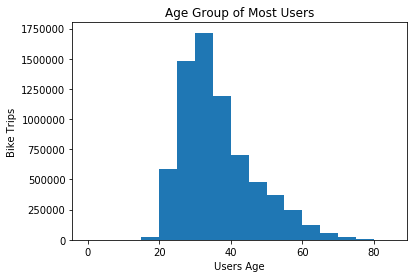

```python
#Creating a histogram for the age group that are using the most
bins = np.arange(0, 90, 5)
plt.hist(data = clean_df, x = 'user_age', bins = bins);
plt.title("Age Group of Most Users");
plt.xlabel('Users Age');
plt.ylabel('Bike Trips');
```

The above histogram shows us that most users are between the age of 20 to 40 and gives us a right skewed histogram. This brings up to investigate the amount of users that are Male vs Female.

### Male vs Female users

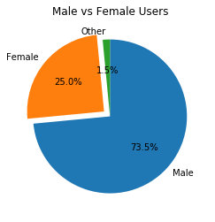

```python
gender_counts = clean_df.member_gender.value_counts()
explode = (0, 0.1, 0)
plt.pie(gender_counts, explode = explode, labels = gender_counts.index, autopct = '%1.1f%%', startangle = 90, counterclock = False);
plt.title('Male vs Female Users');
```

The Male vs Female scenario here shows us that a little under 75% of the users are Male, this could mean a variety of things that we cannot look into with the current dataset. Lets see if there are more subscribers vs customer.

### Customer vs Subscriber

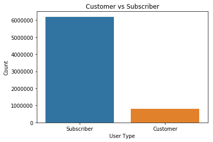

```python
sb.countplot(data = clean_df, x = 'user_type')
plt.title('Customer vs Subscriber');
plt.xlabel('User Type');
plt.ylabel('Count');
```

Looks like there are more members/users subscribed rather then the casual users that probably use only once in awhile. We can wonder if age has anything to do with it?

### Discuss the distribution(s) of your variable(s) of interest. Were there any unusual points? Did you need to perform any transformations?

> The distribution of all points seem rather normal and expected, except the age. Bike riders over the age of 90 seems highly unlikely but not impossible. For that reason, I decided to only display users under the age of 90.

### Of the features you investigated, were there any unusual distributions? Did you perform any operations on the data to tidy, adjust, or change the form of the data? If so, why did you do this?

> Again, nothing to unusual, but I did however tidy up some data. The data that required some tidying was the age group as it was a float and just the birth year. Calculating it to todays year helped in determining what the actual age was.

## Bivariate Exploration

```python
#Create a field for age groups
clean_df['user_age_bins'] = clean_df['user_age'].apply(lambda x: '10 - 24' if 10<x<=24
                                                          else '25 - 39' if 24<x<=39
                                                          else '40 - 54' if 39<x<=54
                                                          else '55 - 69' if 54<x<=69
                                                          else '70 - 89' if 69<x<=89
                                                          else x)
```

### Age Make a Difference?

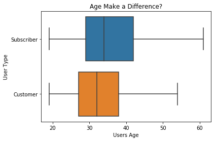

```python
sb.boxplot(data = clean_df, x = 'user_age', y = 'user_type', showfliers=False);
plt.title('Age Make a Difference?');
plt.xlabel('Users Age');
plt.ylabel('User Type');
```

The graph above displays more subscribers as we previously saw but we notice that the majority of users average to be around the same age. Maybe the age and time of the year? We can see the data between user age and hour of the day to get a little more information. We may also need to clean some more for gathering months, days and hours.

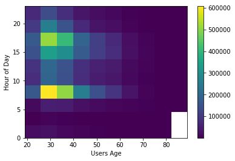

```python
start_month_counts = clean_df.start_month.value_counts()
plt.hist2d(data = clean_df, x = 'user_age', y = 'start_hour', cmin = 0.5);
plt.colorbar()
plt.xlabel('Users Age');
plt.ylabel('Hour of Day');
```

The busiest time of the day is from 6 AM to 9 AM, then we see a decline in usage until 4 PM to 6 PM. This again are the working class going to work, then leaving work. A very healthy community.

### What month GoBike is used the most

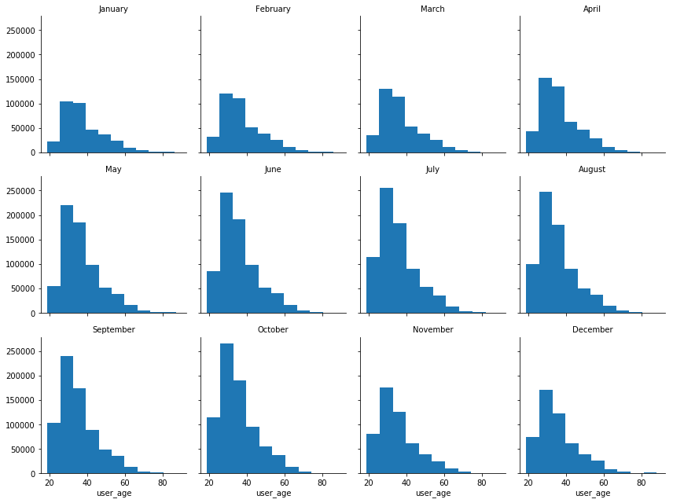

```python
bin_edges = np.arange(18, 89+2, 2)
g = sb.FacetGrid(data = clean_df, col = 'start_month', col_wrap = 4);
g.map(plt.hist, 'user_age');
g.set_titles('{col_name}');
```

The age of users is about the same where ages 20 to 40 seem to have the most usage, but we see a drop in usage. November seems to be where the decline starts to significantly drop up until April.

### Talk about some of the relationships you observed in this part of the investigation. How did the feature(s) of interest vary with other features in the dataset?

> I noticed a difference in users and usage. Users in general seem to be in the prime of the working class commuting to work. This is interesting because this gives us information that the working class are relying on this form of transportation to and from work. The other visualization is we notice from November to April, the usage drops significantly. This must mean it may be to cold for a lot of users, which explains the drop.

### Did you observe any interesting relationships between the other features (not the main feature(s) of interest)?

> Since we see the biggest users are the working class, does the time of the month affect the gender usage?

## Multivariate Exploration

### Month, Age, and Gender Affect Usage

```python
#month = ['January', 'February', 'March', 'April', 'May', 'June', 'July', 'August', 'September', 'October', 'November', 'December']
#months = pd.api.types.CategoricalDtype(ordered = True, categories = month)
#clean_df['start_month'] = clean_df['start_month'].astype(months)
#testify = clean_df.loc[clean_df['member_gender'].isin(['Male', 'Female', 'Other'])]
```

```python
#q = sb.boxplot(data = testify, x = 'start_month', y = 'user_age', hue = 'member_gender', fliersize = 1)
#q.legend(loc = 6, bbox_to_anchor = (1.0, 0.5))
#plt.xticks(rotation = 45)
```

```python
age_gender_month = clean_df[clean_df['user_type'] == 'Subscriber'].groupby(['start_month', 'user_age', 'member_gender']).agg({'bike_id':'count'}).reset_index()
```

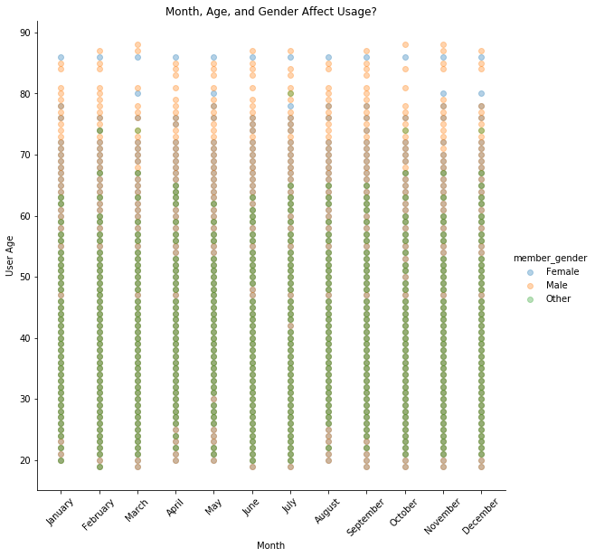

```python
month = ['January', 'February', 'March', 'April', 'May', 'June', 'July', 'August', 'September', 'October', 'November', 'December']
#s = sb.FacetGrid(data = age_gender_month, x = 'start_month', y = 'user_age', hue = 'member_gender', order = month)
s = sb.FacetGrid(data = age_gender_month, hue = 'member_gender', size = 8)
s.map(plt.scatter, 'start_month', 'user_age', alpha = 1/3)
s.add_legend()
plt.title('Month, Age, and Gender Affect Usage?')
#tick_locs = [10, 20, 30, 40, 50, 60, 80]
#plt.yticks(tick_locs)
plt.xlabel('Month')
plt.ylabel('User Age')
s.set_xticklabels(month, rotation = 45);
```

```python
age_gender_month = clean_df[clean_df['user_type'] == 'Customer'].groupby(['start_month', 'user_age', 'member_gender']).agg({'bike_id':'count'}).reset_index()
```

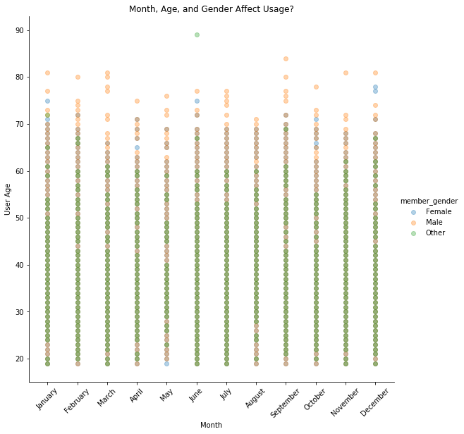

```python
month = ['January', 'February', 'March', 'April', 'May', 'June', 'July', 'August', 'September', 'October', 'November', 'December']
#s = sb.FacetGrid(data = age_gender_month, x = 'start_month', y = 'user_age', hue = 'member_gender', order = month)
s = sb.FacetGrid(data = age_gender_month, hue = 'member_gender', size = 8)
s.map(plt.scatter, 'start_month', 'user_age', alpha = 1/3)
s.add_legend()
plt.title('Month, Age, and Gender Affect Usage?')
#tick_locs = [10, 20, 30, 40, 50, 60, 80]
#plt.yticks(tick_locs)
plt.xlabel('Month')
plt.ylabel('User Age')
s.set_xticklabels(month, rotation = 45);
```

### Talk about some of the relationships you observed in this part of the investigation. Were there features that strengthened each other in terms of looking at your feature(s) of interest?

> My goal here was to observe the correlation between the month, age, and gender. In terms of gender, there wasn't a significant change, but we know more about FordGo Bike users.

### Were there any interesting or surprising interactions between features?

> Here was probably the biggest find! We see now that subscribers have the highest amount of users whether they are lying about their age or not. This is great news for the company as they are users who keep coming back, though may need to somehow attract more Female users. As for the customer users, there was no significant change besides the lower age range of users.

## Sources

> 1. https://medium.com/@kadek/elegantly-reading-multiple-csvs-into-pandas-e1a76843b688
> 2. https://medium.com/@kvnamipara/a-better-visualisation-of-pie-charts-by-matplotlib-935b7667d77f
> 3. https://pandas.pydata.org/pandas-docs/stable/reference/api/pandas.Series.dt.strftime.html
> 4. https://www.geeksforgeeks.org/python-pandas-series-dt-strftime/